# Ch7 Positioning

Once all geoms have a location-based representation, the next step is to transform each location into the new coordinate system. It is easy to transform points, because a point is still a point no matter what coordinate system you are in. Lines and polygons are harder, because a straight line may no longer be straight in the new coordinate system. To make the problem tractable we assume that all coordinate transformations are smooth, in the sense that all very short lines will still be very short straight lines in the new coordinate system. With this assumption in hand, we can transform lines and polygons by breaking them up into many small line segments and transforming each segment. This process is called munching and is illustrated below:

1. We start with a line parameterised by its two endpoints:

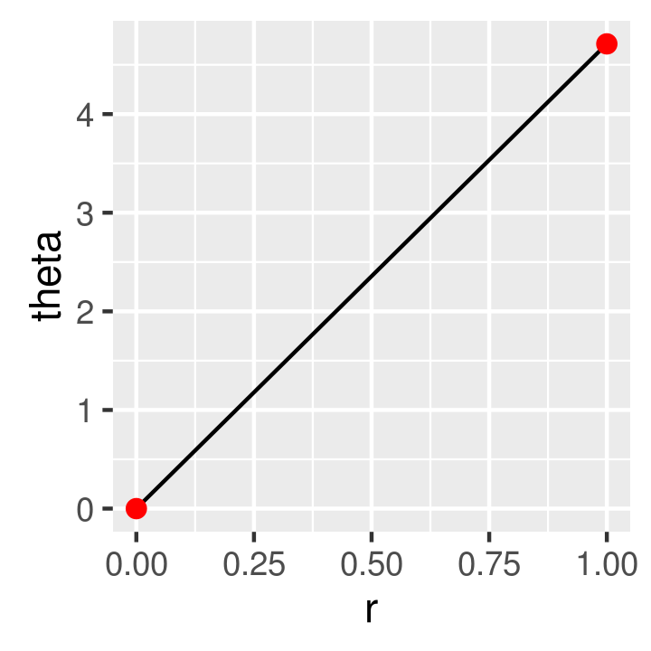

   ```r
   df <- data.frame(r = c(0, 1), theta = c(0, 3 / 2 * pi))
   ggplot(df, aes(r, theta)) +
     geom_line() +
     geom_point(size = 2, colour = "red")
   ```

2. We break it into multiple line segments, each with two endpoints.

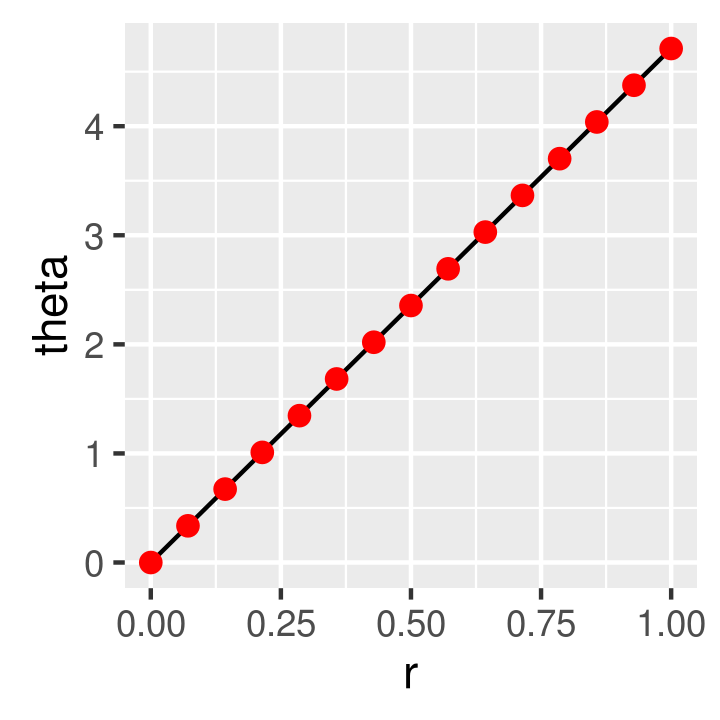

   ```r
   interp <- function(rng, n) {
     seq(rng[1], rng[2], length = n)
   }
   munched <- data.frame(
     r = interp(df$r, 15),
     theta = interp(df$theta, 15)
   )

   ggplot(munched, aes(r, theta)) +
     geom_line() +
     geom_point(size = 2, colour = "red")
   ```

3. We transform the locations of each piece:

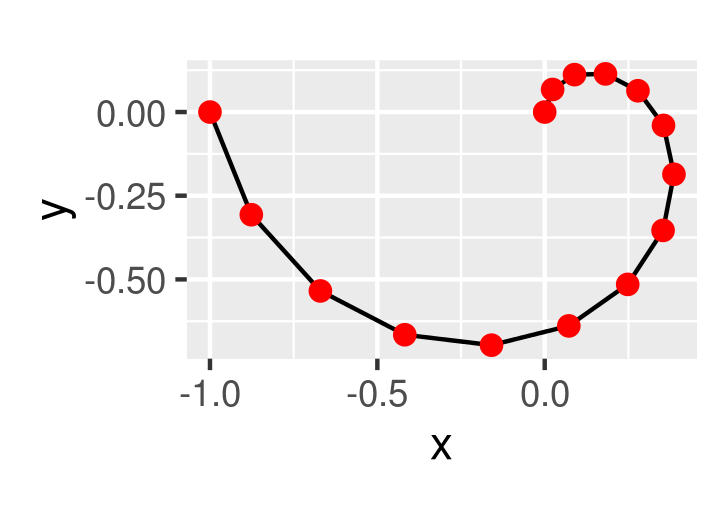

   ```r
   transformed <- transform(munched,
     x = r * sin(theta),
     y = r * cos(theta)
   )

   ggplot(transformed, aes(x, y)) +
     geom_path() +
     geom_point(size = 2, colour = "red") +
     coord_fixed()
   ```

Internally ggplot2 uses many more segments so that the result looks smooth.

### Transformations with `coord_trans()`

Like limits, we can also transform the data in two places: at the scale level or at the coordinate system level. `coord_trans()` has arguments `x` and `y` which should be strings naming the transformer or transformer objects (see continous position scales). Transforming at the scale level occurs before statistics are computed and does not change the shape of the geom. Transforming at the coordinate system level occurs after the statistics have been computed, and does affect the shape of the geom. Using both together allows us to model the data on a transformed scale and then backtransform it for interpretation: a common pattern in analysis.

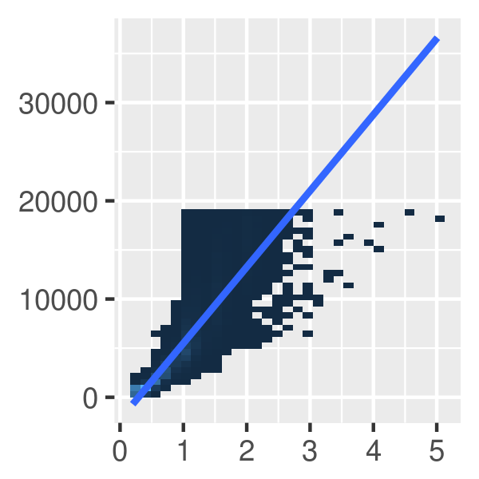

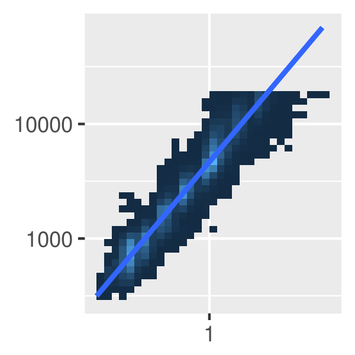

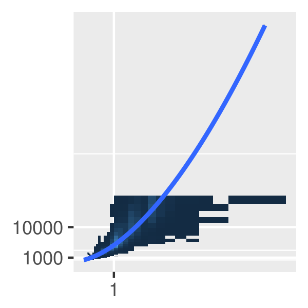

```r
# Linear model on original scale is poor fit
base <- ggplot(diamonds, aes(carat, price)) +
  stat_bin2d() +
  geom_smooth(method = "lm") +
  xlab(NULL) +
  ylab(NULL) +
  theme(legend.position = "none")
base

# Better fit on log scale, but harder to interpret
base +
  scale_x_log10() +
  scale_y_log10()

# Fit on log scale, then backtransform to original.
# Highlights lack of expensive diamonds with large carats
pow10 <- scales::exp_trans(10)
base +
  scale_x_log10() +
  scale_y_log10() +
  coord_trans(x = pow10, y = pow10)
```

### Polar coordinates with `coord_polar()`

Using polar coordinates gives rise to pie charts and wind roses (from bar geoms), and radar charts (from line geoms). Polar coordinates are often used for circular data, particularly time or direction, but the perceptual properties are not good because the angle is harder to perceive for small radii than it is for large radii. The `theta` argument determines which position variable is mapped to angle (by default, x) and which to radius.

The code below shows how we can turn a bar into a pie chart or a bullseye chart by changing the coordinate system. The documentation includes other examples.

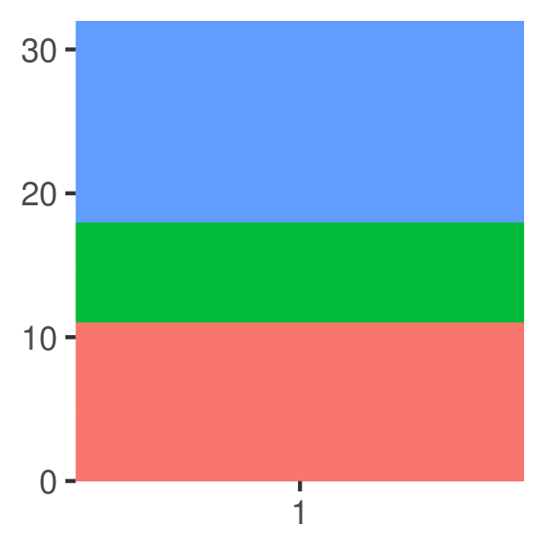

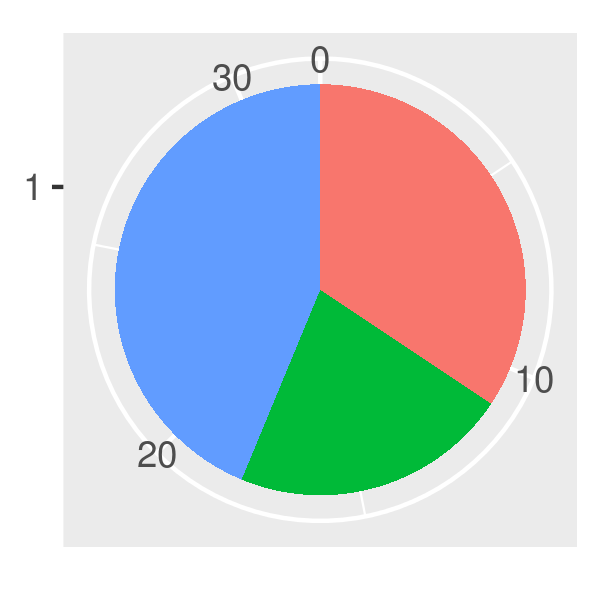

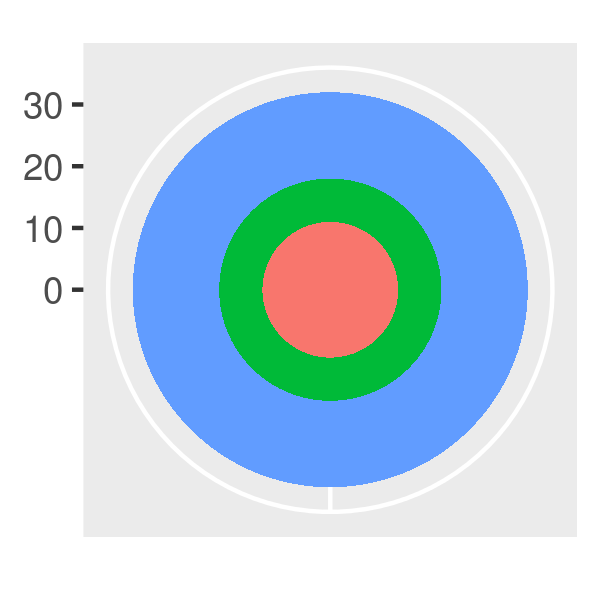

```r
base <- ggplot(mtcars, aes(factor(1), fill = factor(cyl))) +
  geom_bar(width = 1) +
  theme(legend.position = "none") +
  scale_x_discrete(NULL, expand = c(0, 0)) +
  scale_y_continuous(NULL, expand = c(0, 0))

# Stacked barchart
base

# Pie chart
base + coord_polar(theta = "y")

# The bullseye chart
base + coord_polar()
```

### Map projections with `coord_map()`

Maps are intrinsically displays of spherical data. Simply plotting raw longitudes and latitudes is misleading, so we must *project* the data. There are two ways to do this with ggplot2:

- `coord_quickmap()` is a quick and dirty approximation that sets the aspect ratio to ensure than 1m of latitude and 1m of longitude are the same distance in the middle of the plot. These is a reasonable place to start for smaller regions, and is very faster.

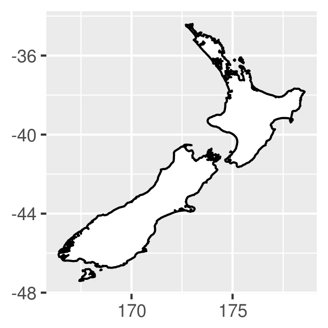

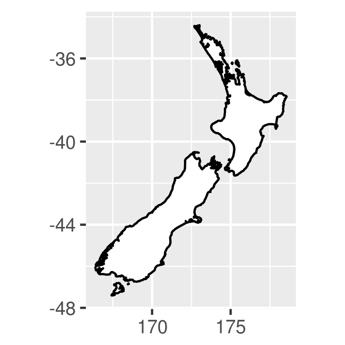

  ```r
  # Prepare a map of NZ
  nzmap <- ggplot(map_data("nz"), aes(long, lat, group = group)) +
    geom_polygon(fill = "white", colour = "black") +
    xlab(NULL) + ylab(NULL)

  # Plot it in cartesian coordinates
  nzmap
  # With the aspect ratio approximation
  nzmap + coord_quickmap()
  ```

- `coord_map()` uses the **mapproj** package, https://cran.r-project.org/package=mapproj to do a formal map projection. It takes the same arguments as `mapproj::mapproject()` for controlling the projection. It is much slower than `coord_quickmap()` because it must munch the data and transform each piece.

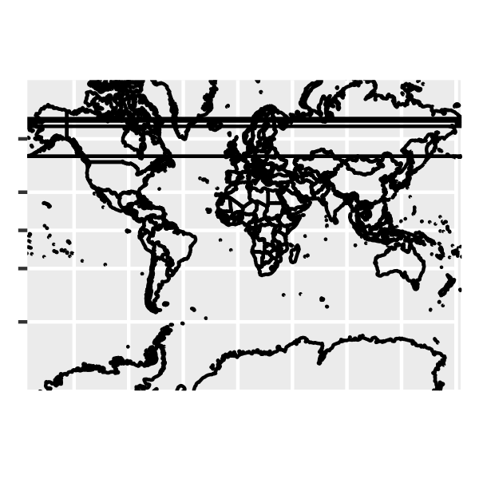

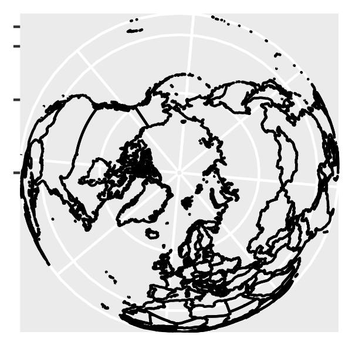

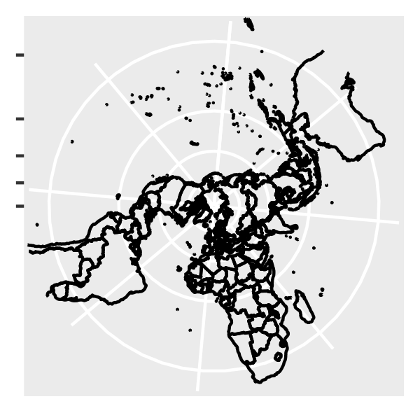

  ```r
  world <- map_data("world")
  worldmap <- ggplot(world, aes(long, lat, group = group)) +
    geom_path() +
    scale_y_continuous(NULL, breaks = (-2:3) * 30, labels = NULL) +
    scale_x_continuous(NULL, breaks = (-4:4) * 45, labels = NULL)

  worldmap + coord_map()
  # Some crazier projections
  worldmap + coord_map("ortho")
  worldmap + coord_map("stereographic")
  ```